# R: Generic autoplot function

| autoplot {ggbio} | R Documentation |
| --- | --- |

## Generic autoplot function

### Description

`autoplot` is a generic function to visualize various data object, it tries to give better default graphics and customized choices for each data type, quick and convenient to explore your genomic data compare to low level `ggplot` method, it is much simpler and easy to produce fairly complicate graphics, though you may lose some flexibility for each layer.

### Usage

```
## S4 method for signature 'GRanges'
autoplot(object, ..., xlab, ylab, main, truncate.gaps = FALSE,
                 truncate.fun = NULL, ratio = 0.0025, space.skip = 0.1,
                 legend = TRUE, geom = NULL, stat = NULL, coord =
                 c("default", "genome", "truncate_gaps"), layout =
                 c("linear", "karyogram", "circle"))


## S4 method for signature 'GRangesList'
autoplot(object, ..., xlab, ylab, main, indName = "grl_name",
                 geom = NULL, stat = NULL, type = c("none", "sashimi"),
                 coverage.col = "gray50", coverage.fill = coverage.col,
                 group.selfish = FALSE, arch.offset = 1.3)


## S4 method for signature 'IRanges'
autoplot(object, ..., xlab, ylab, main)

## S4 method for signature 'Seqinfo'
autoplot(object, single.ideo = TRUE, ... )

## S4 method for signature 'GappedAlignments'
autoplot(object, ..., xlab, ylab, main, which,
      geom = NULL, stat = NULL)

## S4 method for signature 'BamFile'
autoplot(object, ..., which, xlab, ylab, main,
              bsgenome, geom = "line", stat = "coverage",
              method = c("estimate", "raw"),
              coord = c("linear", "genome"), resize.extra = 10,
              space.skip = 0.1, show.coverage = TRUE)

## S4 method for signature 'character'
autoplot(object, ..., xlab, ylab, main, which, asRangedData = FALSE)

## S4 method for signature 'TranscriptDb'
autoplot(object, which, ..., xlab, ylab, main, truncate.gaps =
                 FALSE, truncate.fun = NULL, ratio = 0.0025, geom =
                 c("alignment"), stat = c("identity", "reduce"),
                 names.expr = "tx_name(gene_id)")
```

[output cut: 34 more lines]

```
## S4 method for signature 'SummarizedExperiment'
autoplot(object, ..., type = c("heatmap", "link", "pcp",
                 "boxplot", "scatterplot.matrix"), pheno.plot = FALSE,
                 main_to_pheno = 4.5, padding = 0.2, assay.id = 1)


## S4 method for signature 'VCF'
autoplot(object, ...,
              xlab, ylab, main,
              assay.id,
              type = c("geno", "info", "fixed"),
              full.string = FALSE,
              ref.show = TRUE,
              genome.axis = TRUE,
              transpose = TRUE)
```

### Arguments

[output not shown]

### Value

A `ggplot` object, so you can use common features from ggplot2 package to manipulate the plot.

### Introduction

`autoplot` is redefined as generic s4 method inside this package, user could use `autoplot` in the way they are familiar with, and we are also setting limitation inside this package, like

- scales X scales is always genomic coordinates in most cases, x could be specified as start/end/midpoint when it's special geoms for interval data like point/line
- colors Try to use default color scheme defined in biovizBase package as possible as it can

### Geometry

We have developed new `geom` for different objects, some of them may require extra parameters you need to provide. Some of the geom are more like geom + stat in ggplot2 package. e.g. "coverage.line" and "coverage.polygon".We simply combine them together, but in the future, we plan to make it more general.

This package is designed for only biological data, especially genomic data if users want to explore the data in a more flexible way, you could simply coerce the `GRanges` to a data.frame, then just use formal `autoplot` function in ggplot2, or `autoplot` generic for `data.frame`.

Some objects share the same geom so we introduce all the geom together in this section

**full**

Showing all the intervals as stepped rectangle, colored by strand automatically.

For `TranscripDb` object, showing full model.

**segment**

Showing all the intervals as stepped segments, colored by strand automatically.

For object `BSgenome`, show nucleotides as colored segment.

For Rle/RleList, show histogram-like segments.

**line**

Showing interval as line, the interval data could also be just single position when start = end, x is one of start/end/midpoint, y value is unquoted name in elementMetadata column names. y value is required.

**point**

Showing interval as point, the interval data could also be just single position when start = end, x is one of start/end/midpoint, y value is unquoted name in elementMetadata column names. y value is required.

For object `BSgenome`, show nucleotides as colored point.

**coverage.line**

Coverage showing as lines for interval data.

**coverage.polygon**

Coverage showing as polygon for interval data.

**splice**

Splicing summary. The size and width of the line and rectangle should represent the counts in each model. Need to provide model.

**single**

For `TranscripDb` object, showing single(reduced) model only.

**tx**

For `TranscripDb` object, showing transcirpts isoforms.

**mismatch.summary**

Showing color coded mismatched stacked bar to indicate the proportion of mismatching at each position, the reference is set to gray.

**text**

For object `BSgenome`, show nucleotides as colored text.

**rectangle**

For object `BSgenome`, show nucleotides as colored rectangle.

### Faceting

Faceting in ggbio package is a little differnt from ggplot2 in several ways

- The faceted column could only be seqnames or regions on the genome. So we limited the formula passing to facet argument, e.g something \~ seqnames, is accepted formula, you can change "something" to variable name in the elementMetadata. But you can not change the second part.
- Sometime, we need to view different regions, so we also have a facet_gr argument which accept a `GRanges`. If this is provided, it will override the default seqnames and use provided region to facet the graphics, this might be useful for different gene centric views.

### Author(s)

Tengfei Yin

### Examples

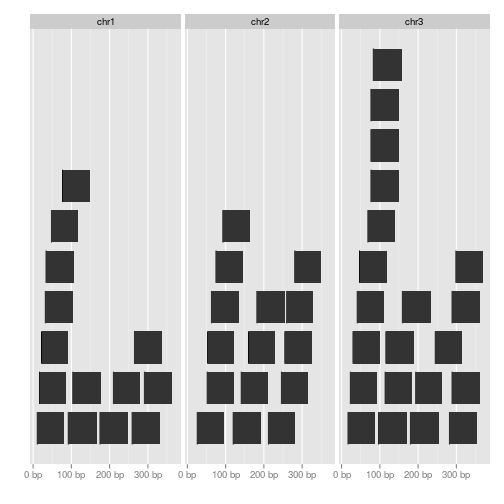

```r
### R code from vignette source 'autoplot.Rnw'
###################################################
### code chunk number 1: load
###################################################
library(ggbio)
###################################################
### code chunk number 2: simul
###################################################
set.seed(1)
N <- 1000
library(GenomicRanges)
gr <- GRanges(seqnames =
              sample(c("chr1", "chr2", "chr3"),
                     size = N, replace = TRUE),
              IRanges(
                      start = sample(1:300, size = N, replace = TRUE),
                      width = sample(70:75, size = N,replace = TRUE)),
              strand = sample(c("+", "-", "*"), size = N,
                replace = TRUE),
              value = rnorm(N, 10, 3), score = rnorm(N, 100, 30),
              sample = sample(c("Normal", "Tumor"),
                size = N, replace = TRUE),
              pair = sample(letters, size = N,
                replace = TRUE))
idx <- sample(1:length(gr), size = 50)
###################################################
### code chunk number 3: default
###################################################
autoplot(gr[idx])
```

```r
###################################################
### code chunk number 4: bar-default-pre
###################################################
set.seed(123)
gr.b <- GRanges(seqnames = "chr1", IRanges(start = seq(1, 100, by = 10),
                  width = sample(4:9, size = 10, replace = TRUE)),
                score = rnorm(10, 10, 3), value = runif(10, 1, 100))
gr.b2 <- GRanges(seqnames = "chr2", IRanges(start = seq(1, 100, by = 10),
                  width = sample(4:9, size = 10, replace = TRUE)),
                score = rnorm(10, 10, 3), value = runif(10, 1, 100))
gr.b <- c(gr.b, gr.b2)
head(gr.b)
```

```
## GRanges with 6 ranges and 2 metadata columns:
##       seqnames    ranges strand |            score            value
##          <Rle> <IRanges>  <Rle> |        <numeric>        <numeric>
##   [1]     chr1  [ 1,  5]      * | 15.1451949606498 96.3393990211189
##   [2]     chr1  [11, 18]      * | 11.3827486179676  90.327605466824
##   [3]     chr1  [21, 26]      * |  6.2048162961804 69.3798225638457
##   [4]     chr1  [31, 39]      * | 7.93944144431942 79.7512743510306
##   [5]     chr1  [41, 49]      * | 8.66301408970013   3.436754766386
##   [6]     chr1  [51, 54]      * | 13.6722453923184 48.3018011380918
##   ---
##   seqlengths:
##    chr1 chr2
##      NA   NA
```

```r
###################################################
### code chunk number 5: bar-default
###################################################
p1 <- autoplot(gr.b, geom = "bar")
```

```
## use score as y by default
```

```r
## use value to fill the bar
p2 <- autoplot(gr.b, geom = "bar", aes(fill = value))
```

```
## use score as y by default
```

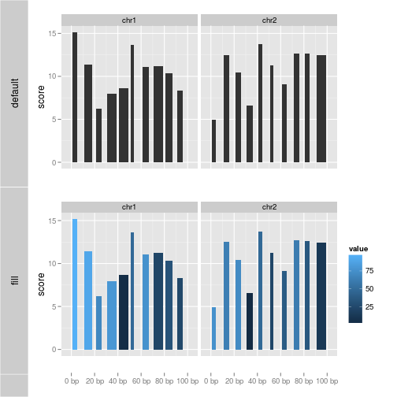

```r
tracks(default = p1, fill = p2)
```

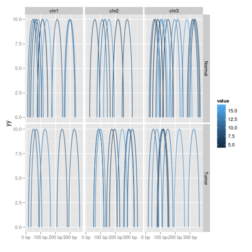

```r
###################################################
### code chunk number 6: autoplot.Rnw:236-237
###################################################
autoplot(gr[idx], geom = "arch", aes(color = value), facets = sample ~ seqnames)
```

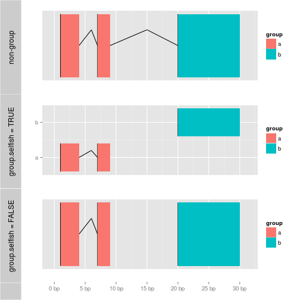

```r
###################################################
### code chunk number 7: gr-group
###################################################
gra <- GRanges("chr1", IRanges(c(1,7,20), end = c(4,9,30)), group = c("a", "a", "b"))
## if you desn't specify group, then group based on stepping levels, and gaps are computed without
## considering extra group method
p1 <- autoplot(gra, aes(fill = group), geom = "alignment")
## when use group method, gaps only computed for grouped intervals.
## default is group.selfish = TRUE, each group keep one row.
## in this way, group labels could be shown as y axis.
p2 <- autoplot(gra, aes(fill = group, group = group), geom = "alignment")
## group.selfish = FALSE, save space
p3 <- autoplot(gra, aes(fill = group, group = group), geom = "alignment", group.selfish = FALSE)
tracks('non-group' = p1,'group.selfish = TRUE' = p2 , 'group.selfish = FALSE' = p3)
```

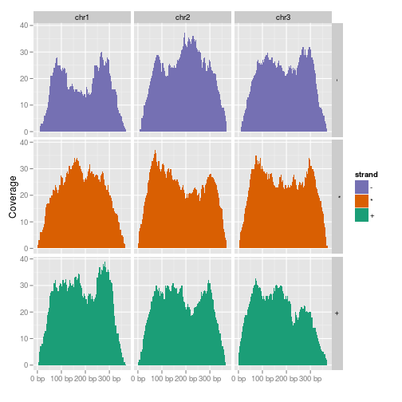

```r
###################################################
### code chunk number 8: gr-facet-strand
###################################################
autoplot(gr, stat = "coverage", geom = "area",
         facets = strand ~ seqnames, aes(fill = strand))
```

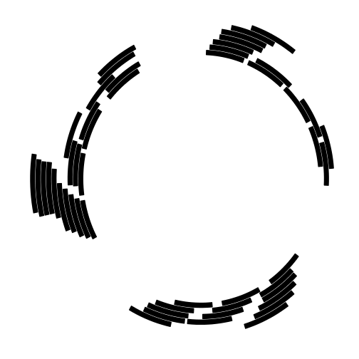

```r
###################################################
### code chunk number 9: gr-autoplot-circle
###################################################
autoplot(gr[idx], layout = 'circle')
```

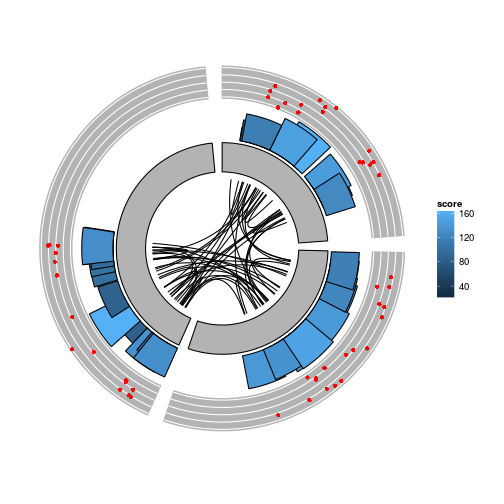

```r
###################################################
### code chunk number 10: gr-circle
###################################################
seqlengths(gr) <- c(400, 500, 700)
values(gr)$to.gr <- gr[sample(1:length(gr), size = length(gr))]
idx <- sample(1:length(gr), size = 50)
gr <- gr[idx]
ggplot() + layout_circle(gr, geom = "ideo", fill = "gray70", radius = 7, trackWidth = 3) +
  layout_circle(gr, geom = "bar", radius = 10, trackWidth = 4,
                aes(fill = score, y = score)) +
  layout_circle(gr, geom = "point", color = "red", radius = 14,
                trackWidth = 3, grid = TRUE, aes(y = score)) +
  layout_circle(gr, geom = "link", linked.to = "to.gr", radius = 6, trackWidth = 1)
```

```r
###################################################
### code chunk number 11: seqinfo-src
###################################################
data(hg19Ideogram, package = "biovizBase")
sq <- seqinfo(hg19Ideogram)
sq
```

```
## Seqinfo of length 93
## seqnames             seqlengths isCircular genome
## chr1                  249250621       <NA>   hg19
## chr1_gl000191_random     106433       <NA>   hg19
## chr1_gl000192_random     547496       <NA>   hg19
## chr2                  243199373       <NA>   hg19
## chr3                  198022430       <NA>   hg19
## chr4                  191154276       <NA>   hg19
## chr4_ctg9_hap1           590426       <NA>   hg19
## chr4_gl000193_random     189789       <NA>   hg19
## chr4_gl000194_random     191469       <NA>   hg19
## ...                         ...        ...    ...
## chrUn_gl000242            43523       <NA>   hg19
## chrUn_gl000243            43341       <NA>   hg19
## chrUn_gl000244            39929       <NA>   hg19
## chrUn_gl000245            36651       <NA>   hg19
## chrUn_gl000246            38154       <NA>   hg19
## chrUn_gl000247            36422       <NA>   hg19
## chrUn_gl000248            39786       <NA>   hg19
## chrUn_gl000249            38502       <NA>   hg19
## chrM                      16571       <NA>   hg19
```

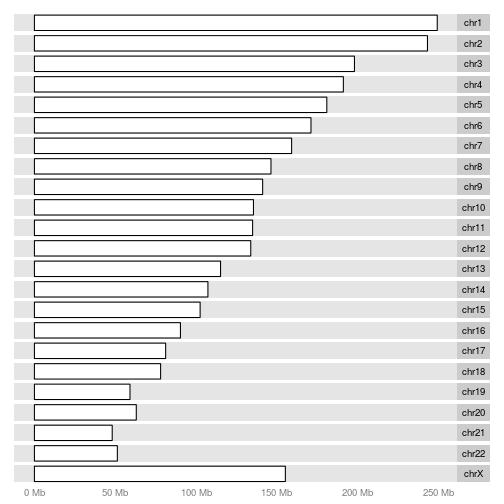

```r
###################################################
### code chunk number 12: seqinfo
###################################################
autoplot(sq[paste0("chr", c(1:22, "X"))])
```

```r
###################################################
### code chunk number 13: ir-load
###################################################
set.seed(1)
N <- 100
ir <-  IRanges(start = sample(1:300, size = N, replace = TRUE),
               width = sample(70:75, size = N,replace = TRUE))
## add meta data
df <- DataFrame(value = rnorm(N, 10, 3), score = rnorm(N, 100, 30),
              sample = sample(c("Normal", "Tumor"),
                size = N, replace = TRUE),
              pair = sample(letters, size = N,
                replace = TRUE))
values(ir) <- df
ir
```

```
## IRanges of length 100
##       start end width
## [1]      80 152    73
## [2]     112 183    72
## [3]     172 242    71
## [4]     273 347    75
## [5]      61 133    73
## [6]     270 340    71
## [7]     284 353    70
## [8]     199 270    72
## [9]     189 263    75
## ...     ... ...   ...
## [92]     18  89    72
## [93]    193 262    70
## [94]    263 337    75
## [95]    234 304    71
## [96]    240 312    73
## [97]    137 206    70
## [98]    124 198    75
## [99]    244 314    71
## [100]   182 255    74
```

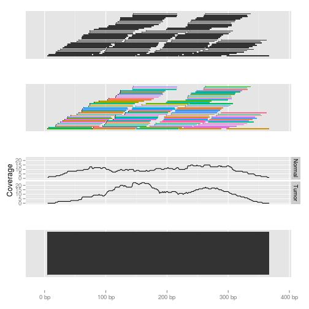

```r
###################################################
### code chunk number 14: ir-exp
###################################################
p1 <- autoplot(ir)
p2 <- autoplot(ir, aes(fill = pair)) + theme(legend.position = "none")
p3 <- autoplot(ir, stat = "coverage", geom = "line", facets = sample ~. )
p4 <- autoplot(ir, stat = "reduce")
tracks(p1, p2, p3, p4)
```

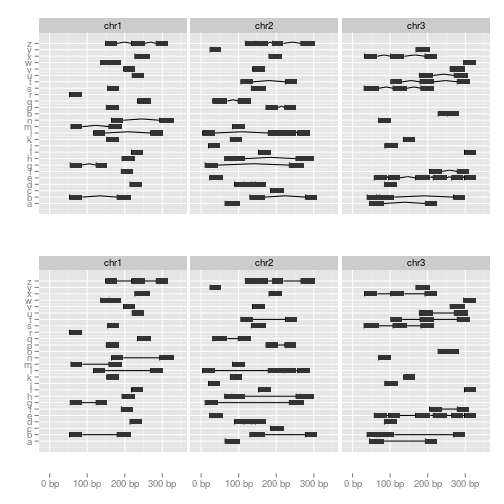

```r
###################################################
### code chunk number 15: grl-simul
###################################################
set.seed(1)
N <- 100
## ======================================================================
##  simmulated GRanges
## ======================================================================
gr <- GRanges(seqnames =
              sample(c("chr1", "chr2", "chr3"),
                     size = N, replace = TRUE),
              IRanges(
                      start = sample(1:300, size = N, replace = TRUE),
                      width = sample(30:40, size = N,replace = TRUE)),
              strand = sample(c("+", "-", "*"), size = N,
                replace = TRUE),
              value = rnorm(N, 10, 3), score = rnorm(N, 100, 30),
              sample = sample(c("Normal", "Tumor"),
                size = N, replace = TRUE),
              pair = sample(letters, size = N,
                replace = TRUE))
grl <- split(gr, values(gr)$pair)
###################################################
### code chunk number 16: grl-exp
###################################################
## default gap.geom is 'chevron'
p1 <- autoplot(grl, group.selfish = TRUE)
p2 <- autoplot(grl, group.selfish = TRUE, main.geom = "arrowrect", gap.geom = "segment")
tracks(p1, p2)
```

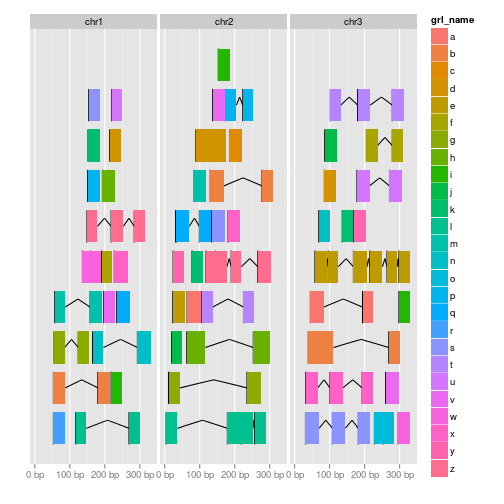

```r
###################################################
### code chunk number 17: grl-name
###################################################
autoplot(grl, aes(fill = ..grl_name..))
```

```r
## equal to
## autoplot(grl, aes(fill = grl_name))
###################################################
### code chunk number 18: rle-simul
###################################################
library(IRanges)
library(ggbio)
set.seed(1)
lambda <- c(rep(0.001, 4500), seq(0.001, 10, length = 500),
            seq(10, 0.001, length = 500))
## @knitr create
xVector <- rpois(1e4, lambda)
xRle <- Rle(xVector)
xRle
```

```
## numeric-Rle of length 10000 with 823 runs
##   Lengths:  779    1  208    1 1599    1 ...    1    5    2    9    1 4507
##   Values :    0    1    0    1    0    1 ...    1    0    1    0    1    0
```

```r
###################################################
### code chunk number 19: rle-bin
###################################################
p1 <- autoplot(xRle)
```

```
## Default use binwidth: range/30
```

```r
p2 <- autoplot(xRle, nbin = 80)
```

```
## Default use binwidth: range/80
```

```r
p3 <- autoplot(xRle, geom = "heatmap", nbin = 200)
```

```
## Default use binwidth: range/200
```

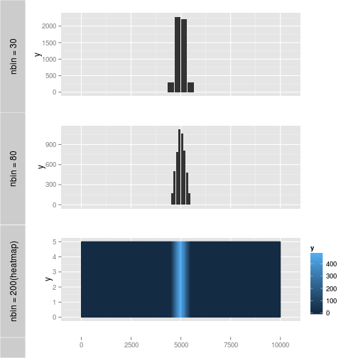

```r
tracks('nbin = 30' = p1, "nbin = 80" = p2, "nbin = 200(heatmap)" = p3)
```

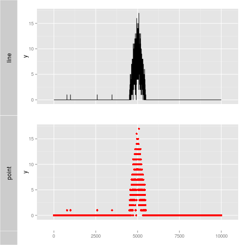

```r
###################################################
### code chunk number 20: rle-id
###################################################
p1 <- autoplot(xRle, stat = "identity")
p2 <- autoplot(xRle, stat = "identity", geom = "point", color = "red")
tracks('line' = p1, "point" = p2)
```

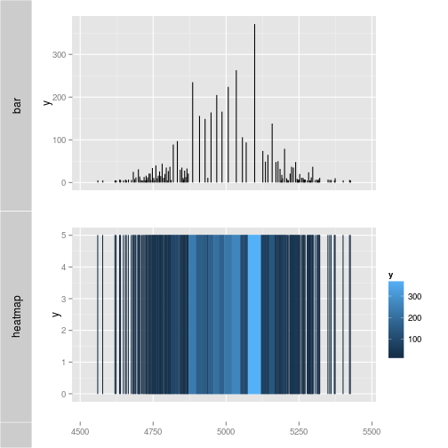

```r
###################################################
### code chunk number 21: rle-slice
###################################################
p1 <- autoplot(xRle, type = "viewMaxs", stat = "slice", lower = 5)
p2 <- autoplot(xRle, type = "viewMaxs", stat = "slice", lower = 5, geom = "heatmap")
tracks('bar' = p1, "heatmap" = p2)
```

```r
###################################################
### code chunk number 22: rlel-simul
###################################################
xRleList <- RleList(xRle, 2L * xRle)
xRleList
```

```
## SimpleRleList of length 2
## [[1]]
## numeric-Rle of length 10000 with 823 runs
##   Lengths:  779    1  208    1 1599    1 ...    1    5    2    9    1 4507
##   Values :    0    1    0    1    0    1 ...    1    0    1    0    1    0
##
## [[2]]
## numeric-Rle of length 10000 with 823 runs
##   Lengths:  779    1  208    1 1599    1 ...    1    5    2    9    1 4507
##   Values :    0    2    0    2    0    2 ...    2    0    2    0    2    0
```

```r
###################################################
### code chunk number 23: rlel-bin
###################################################
p1 <- autoplot(xRleList)
```

```
## Default use binwidth: range/30
```

```r
p2 <- autoplot(xRleList, nbin = 80)
```

```
## Default use binwidth: range/80
```

```r
p3 <- autoplot(xRleList, geom = "heatmap", nbin = 200)
```

```
## Default use binwidth: range/200
```

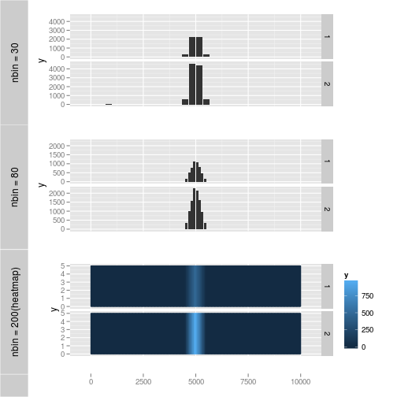

```r
tracks('nbin = 30' = p1, "nbin = 80" = p2, "nbin = 200(heatmap)" = p3)
```

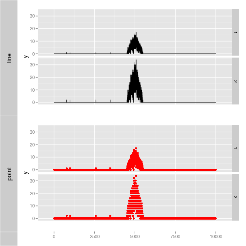

```r
###################################################
### code chunk number 24: rlel-id
###################################################
p1 <- autoplot(xRleList, stat = "identity")
p2 <- autoplot(xRleList, stat = "identity", geom = "point", color = "red")
tracks('line' = p1, "point" = p2)
```

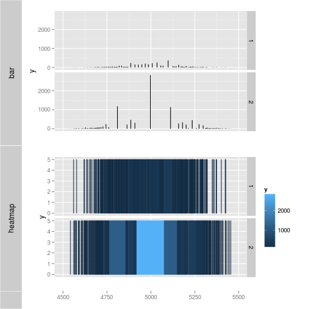

```r
###################################################
### code chunk number 25: rlel-slice
###################################################
p1 <- autoplot(xRleList, type = "viewMaxs", stat = "slice", lower = 5)
p2 <- autoplot(xRleList, type = "viewMaxs", stat = "slice", lower = 5, geom = "heatmap")
tracks('bar' = p1, "heatmap" = p2)
```

```r
###################################################
### code chunk number 26: txdb
###################################################
library(TxDb.Hsapiens.UCSC.hg19.knownGene)
```

```r
data(genesymbol, package = "biovizBase")
txdb <- TxDb.Hsapiens.UCSC.hg19.knownGene
###################################################
### code chunk number 27: txdb-visual
###################################################
p1 <- autoplot(txdb, which = genesymbol["ALDOA"], names.expr = "tx_name:::gene_id")
```

```
## Aggregating TranscriptDb...
```

```
## Parsing exons...
```

```
## Parsing cds...
```

```
## Parsing transcripts...
```

```
## Aggregating...
```

```
## Done
```

```
## Constructing graphics...
```

```r
p2 <- autoplot(txdb, which = genesymbol["ALDOA"], stat = "reduce", color = "brown",
               fill = "brown")
```

```
## Aggregating TranscriptDb...
```

```
## Parsing exons...
```

```
## Parsing cds...
```

```
## Parsing transcripts...
```

```
## Aggregating...
```

```
## Done
```

```
## Constructing graphics...
```

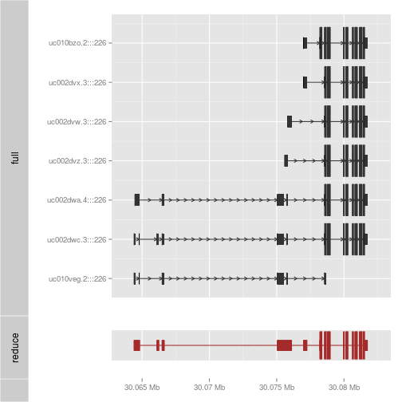

```r
tracks(full = p1, reduce = p2, heights = c(5, 1)) + ylab("")
```

```r
###################################################
### code chunk number 28: ga-load
###################################################
library(Rsamtools)
```

```r
data("genesymbol", package = "biovizBase")
bamfile <- system.file("extdata", "SRR027894subRBM17.bam", package="biovizBase")
## need to set use.names = TRUE
ga <- readBamGappedAlignments(bamfile,
                              param = ScanBamParam(which = genesymbol["RBM17"]),
                              use.names = TRUE)
###################################################
### code chunk number 29: ga-exp
###################################################
p1 <- autoplot(ga)
p2 <- autoplot(ga, geom = "rect")
```

```
## extracting information...
```

```r
p3 <- autoplot(ga, geom = "line", stat = "coverage")
```

```
## extracting information...
```

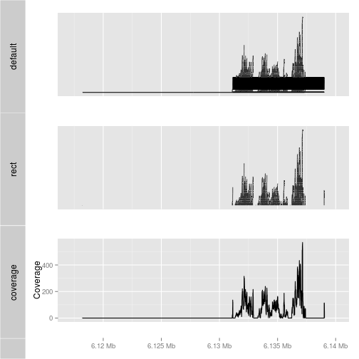

```r
tracks(default = p1, rect = p2, coverage = p3)
```

```
## reading in
```

```
## use score as y by default
```

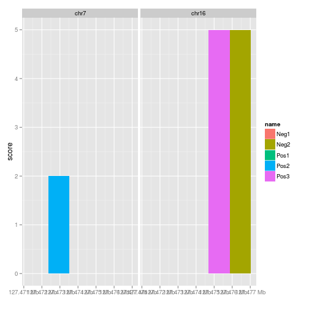

```r
###################################################
### code chunk number 30: bf-load (eval = FALSE)
###################################################
## library(Rsamtools)
## bamfile <- "./wgEncodeCaltechRnaSeqK562R1x75dAlignsRep1V2.bam"
## bf <- BamFile(bamfile)
###################################################
### code chunk number 31: bf-est-cov (eval = FALSE)
###################################################
## autoplot(bamfile)
## autoplot(bamfile, which = c("chr1", "chr2"))
## autoplot(bf)
## autoplot(bf, which = c("chr1", "chr2"))
##
## data(genesymbol, package = "biovizBase")
## autoplot(bamfile,  method = "raw", which = genesymbol["ALDOA"])
##
## library(BSgenome.Hsapiens.UCSC.hg19)
## autoplot(bf, stat = "mismatch", which = genesymbol["ALDOA"], bsgenome = Hsapiens)
###################################################
### code chunk number 32: char-bam (eval = FALSE)
###################################################
## bamfile <- "./wgEncodeCaltechRnaSeqK562R1x75dAlignsRep1V2.bam"
## autoplot(bamfile)
###################################################
### code chunk number 33: char-gr
###################################################
library(rtracklayer)
test_path <- system.file("tests", package = "rtracklayer")
test_bed <- file.path(test_path, "test.bed")
autoplot(test_bed, aes(fill = name))
```

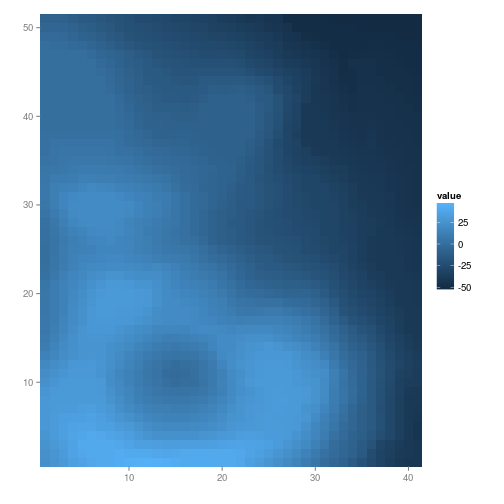

```r
###################################################
###  matrix
###################################################
volcano <- volcano[20:70, 20:60] - 150
autoplot(volcano)
```

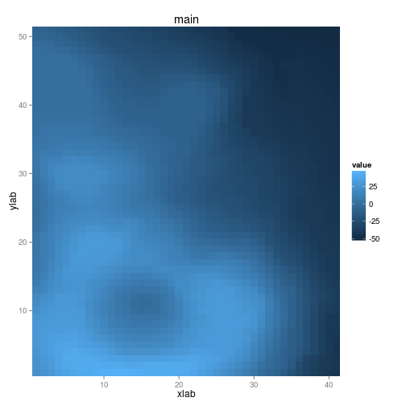

```r
autoplot(volcano, xlab = "xlab", main = "main", ylab = "ylab")
```

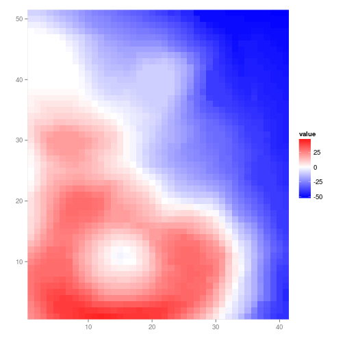

```r
## special scale theme for 0-centered values
autoplot(volcano, geom = "raster")+scale_fill_fold_change()
```

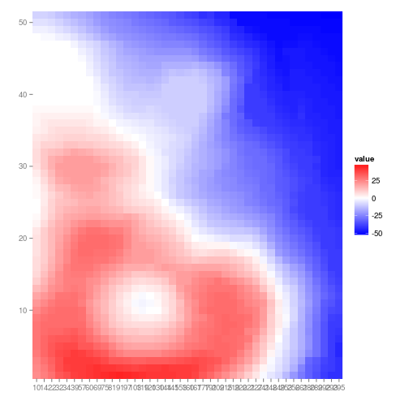

```r
## when a matrix has colnames and rownames label them by default
colnames(volcano) <- sort(sample(1:300, size = ncol(volcano), replace = FALSE))
autoplot(volcano)+scale_fill_fold_change()
```

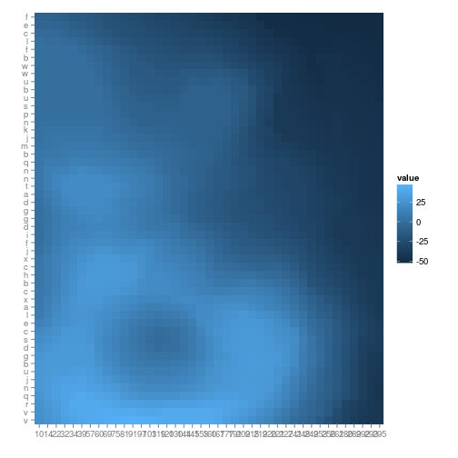

```r
rownames(volcano) <- letters[sample(1:24, size = nrow(volcano), replace = TRUE)]
autoplot(volcano)
```

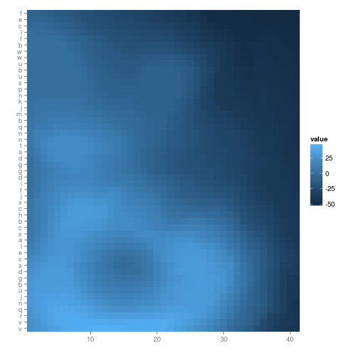

```r
## even with row/col names, you could also disable it and just use numeric index
autoplot(volcano, colnames.label = FALSE)
```

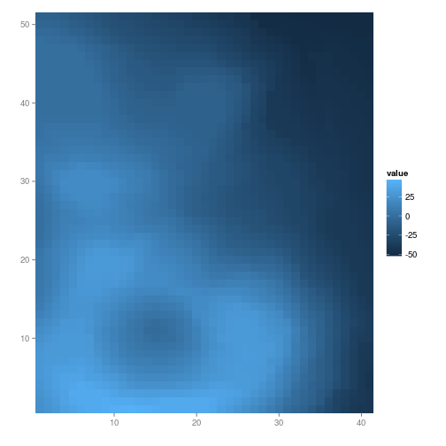

```r
autoplot(volcano, rownames.label = FALSE, colnames.label = FALSE)
```